# Lecture 5

11/09/2019

## Turning Point: Expectation

## First Question

**Question:** Is \(\mathbb{E}[X]\) is the most likely value of \(X\)?

**Answer:** No.

**Why?** The expection does not need to be a value in the support of \(X\). The expection is just the centre of mass. Consider the counterexample where \(X\) is a random variable representing the the toss of a 6 sided die.

\[\mathbb{E}[X] = \sum_{i = 1}^6 x \mathbb{P}(X = x) = \sum_{i = 1}^6 x \cdot \frac{1}{6} = \tfrac{1}{6} + \tfrac{2}{6} + \dots + \tfrac{6}{6} = 3.5\] A roll of 3.5 isn't even possible! In this example, all values are also equally likely.

## First Question (ctd.)

**Question:** Is the \(\mathbb{E}[X]\) is always positive?

**Answer:** No.

**Why?** Again consider a counterexmple. For example a normal distribution, \(N(-10,1)\), the centre of mass of the distribution and the expection is -10.

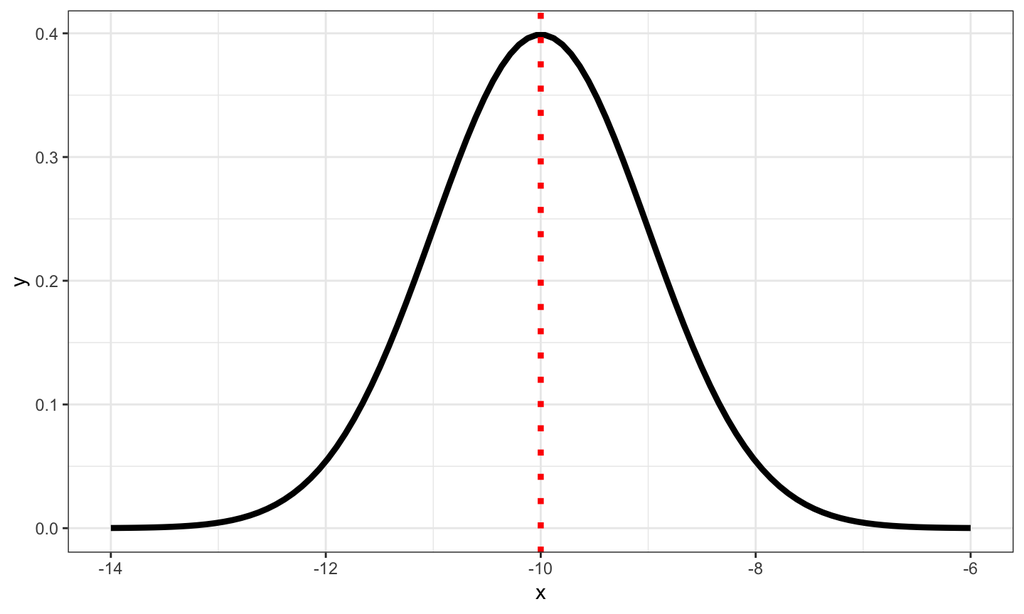

## Second Question

Let \(X\) be a discrete RV with pmf

\[ p(-1) = \tfrac{1}{5}, \quad p(0) = \tfrac{2}{5} \quad \text{and} \quad p(1) = \tfrac{2}{5},\] and let \(Y = X^2\).

**Question:** What is the expection of \(X\) and \(Y\)?

**Answer** \(\tfrac{1}{5}\) and \(\tfrac{3}{5}\).

**Why?**

\[\mathbb{E}[X] = \sum_{i \in \{-1,0,1\}} x \mathbb{P}(X = x) = -1 \cdot \tfrac{1}{5} + 0 \cdot \tfrac{2}{5} + 1 \cdot \tfrac{2}{5} = \tfrac{1}{5}\]

## Second question (ctd.)

The pmf for \(Y\) is then:

\[ p(0) = \tfrac{2}{5} \quad \text{and} \quad p(1) = \tfrac{3}{5}.\]

\[\mathbb{E}[Y] = \sum_{i \in \{0,1\}} y \mathbb{P}(Y = y) = 0 \cdot \tfrac{2}{5} + 1 \cdot \tfrac{3}{5} = \tfrac{3}{5}\]

## Expectations and Examples

## A head's up

- Expectation of binomial uses some cool tricks - be easy in chapter 10, let's leave it for now
- Poisson distribution is going to be an exercise.
- Exponential distribution is going to be an exercise.
- Normal distribution is in the book - it uses the substitution rule

Let's do the Geometric!!

## Geometric

Uses mean of a standard geometric series:

\[ \sum_{i = 0}^\infty ar^(k) = \dfrac{a}{1-r} \quad |r| < 1 \]

## Change of variables

Back to the first question:

\[\mathbb{E}[Y] = \mathbb{E}[X^2] = \sum_{i \in \{-1,0,1\}} x^2 \mathbb{P}(X = x) = 1 \cdot \tfrac{1}{5} + 0 \cdot \tfrac{2}{5} + 1 \cdot \tfrac{2}{5} = \tfrac{3}{5}\]

## Signal arriving

Expectation is the center of mass: so for \(U(0, 2\pi)\) it will be \(\pi\).

Show this mathematically: \[ \mathbb{E}[\theta] = \int_0^{2\pi} \theta f(\theta) \,\text{d}\theta = \int_0^{2\pi} \theta \cdot \tfrac{1}{2\pi} \,\text{d}\theta = \tfrac{\theta^2}{2} \tfrac{1}{2\pi} \Big|_0^{2\pi} = \frac{4\pi^2}{4\pi} = \pi \]

## First example

Remember how to integrate with substitution. Let \(u = f(x)\); \(\frac{\text{d}u}{\text{d}x} = f'(x)\);  
\[ \int f(x + 1) \text{d}x = \int f(u) f'(x) \text{d}x = \int f(u) \text{d}u = F(u).\]

## Second example

Remember about trigonomic substition:

Both statements are trueL

## Statement 1

We can obtain this from \[\text{Var}(X) \geq 0\] and \[\text{Var}(X) = \mathbb{E}\left[X^2\right] - (\mathbb{E}[X])^2\], therefore the statement follows.

## Last Question

Remember the expectation is the centre of mass.

Only in the case of a symmetric distribution, will the centre mass and the median of the support by the same.